Boats Segmentation: Cluster Analysis

Ingmar BAER, Bence BUDAY, Stefanie GRABNER, Christoph VON PLANTA

## Business Decisions

In this assignment, we made a cluster analysis of the Boats dataset, aiming at identifying different segments within the dataset, using the five previously identified factors of importance. After several trial and error rounds, we identified five segments that show clear differences across several characteristics, such as the importance of boats in their lives, the usage of boats, the ownership of a boat, and demographic characteristics such as age and salary. This segment information can be used for targeted marketing and sales activities as well as for product development.

## The Data

This dataset is composed of 29 questions related to customers value perception, usage and purchasing behavior related to boats. In addition, the dataset contains 52 questions about the customers demographics and boat types the customers already owned. More than 1'000 customers participated in this survey.

## Our Approach

1. Confirm the data in metric
2. Decide whether to scale or standardize the data
3. Decide which variables to use for clustering
4. Define similarity or dissimilarity measures between observations
5. Visualize Individual Attributes and Pair-wise Distances between the Observations
6. Select the clustering method to use and decide how many clusters to have
7. Profile and interpret the clusters
8. Assess the robustness of our clusters

Let's follow these steps.

#### 2. Decide whether to scale or standardize the data

```r
ProjectData_scaled = apply(ProjectData, 2, function(r) {
    if (sd(r) != 0)
        res = (r - mean(r))/sd(r) else res = 0 * r
    res
})
```

While this is typically a necessary step, one has to always do it with care: some times you may want your analytics findings to be driven mainly by a few attributes that take large values; other times having attributes with different scales may imply something about those attributes. In many such cases one may choose to skip step 2 for some of the raw attributes.

We decide to use the unscaled data for now.

#### Step 3. Decide which variables to use for clustering

In the previous exercise, we have identified 5 factors that explain a major part of the variance in the dataset. To decide which variables to be used for clustering, we look at the loadings of each of the 29 question related to customers value perceptions, and choose the question with the highest loading for each component. By doing so, we select the following five questions as segmentation variables: 1. Q21: Boating helps me escape from everyday life and relax 2. Q27: Boating is the number one thing I do with my spare time 3. Q09: I see my boat as a status symbol 4. Q04: I only consider buying a boat from a reputable brand 5. Q02: When buying a boat, getting the lowest price is more important than the boat brand

#### Step 4. Define similarity or dissimilarity measures between observations

In our case we explore two distance metrics: the commonly used **Euclidean distance** as well as a simple one we define manually.

Pairwise Distances between the first 5 observations using The Euclidean Distance Metric

| 1 | 2 | 3 | 4 | 5 |
| --- | --- | --- | --- | --- |
| 0.0 |  |  |  |  |
| 2.2 | 0.0 |  |  |  |
| 2.4 | 1.7 | 0.0 |  |  |
| 2.4 | 1.7 | 2.4 | 0.0 |  |
| 1.7 | 1.4 | 2.2 | 2.6 | 0.0 |

Notice for example that if we use, say, the Manhattan distance metric, these distances change as follows:

Pairwise Distances between the first 5 observations using The Manhattan Distance Metric

| 1 | 2 | 3 | 4 | 5 |
| --- | --- | --- | --- | --- |
| 0.0 |  |  |  |  |
| 5.0 | 0.0 |  |  |  |
| 4.0 | 3.0 | 0.0 |  |  |
| 4.0 | 3.0 | 4.0 | 0.0 |  |
| 3.0 | 2.0 | 5.0 | 5.0 | 0.0 |

Let's now define our own distance metric, as an example. Let's say that the management team of the company believes that two customers are similar if they do not differ in their ratings of the attitudinal questions by more than 2 points. We can manually assign a distance of 1 for every question for which two customers gave an answer that differs by more than 2 points, and 0 otherwise. It is easy to write this distance function in R:

```r
My_Distance_function <- function(x, y) {
    sum(abs(x - y) > 2)
}
```

Here is how the pairwise distances between the respondents now look like.

Pairwise Distances between the first 5 observations using a simple manually defined Distance Metric

| 1 | 2 | 3 | 4 | 5 |
| --- | --- | --- | --- | --- |
| 0.0 |  |  |  |  |
| 0.0 | 0.0 |  |  |  |
| 0.0 | 0.0 | 0.0 |  |  |
| 0.0 | 0.0 | 0.0 | 0.0 |  |
| 0.0 | 0.0 | 0.0 | 0.0 | 0.0 |

In general a lot of creative thinking and exploration should be spent in this step, and as always one may need to come back to this step even after finishing the complete segmentation process - multiple times.

#### Step 5. Visualize Individual Attributes and Pair-wise Distances between the Observations

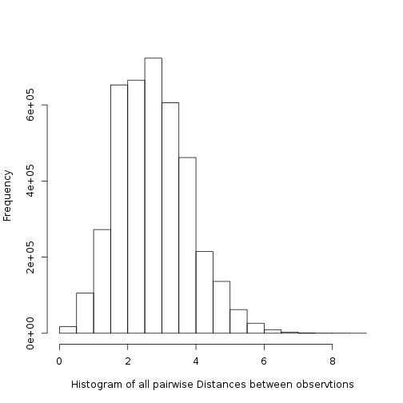

> Visualization is very important for data analytics, as it can provide a first understanding of the data.

#### Step 6. Select the clustering method to use and decide how many clusters to have

We have tried both the Kmeans Clustering Method as well as the Hierarchical Clustering Method. Since the technical differences of these methods are out of scope for this exercise, we have considered both results and decided to use the clustering method that makes most sense to us. When using the Kmeans Clustering Method and 5 clusters, there are clear differences between the clusters, and the outcomes of the different variables are consistent (more on this later). When using fewer clusters, it becomes difficult to explain the cluster characteristics, as several apparently contradictory variables start to appear together. We believe to see this because when grouping the customers in only, for example, 3 groups, we are combining customers that do have very differentiating characteristics. On the other hand, when choosing many more segments, such as 9, it becomes very difficult to explain each segment and find the differentiating elements between them. Thus, we choose 5 clusters for this analysis.

In this note we will use two widely used methods: the **Kmeans Clustering Method**, and the **Hierarchical Clustering Method**. Like all clustering methods, these two also require that we have decided how to measure the distance/similarity between our observations. Explaining how these methods work is beyond our scope. The only difference to highlight is that Kmeans requires the user to define how many segments to create, while Hierarchical Clustering does not.

Let's fist use the **Hierarchial Clustering** method, as we do not know for now how many segments there are in our data. Hierarchical clustering is a method that also helps us visualise how the data may be clustering together. It generates a plot called the **Dendrogram** which is often helpful for visualization - but should be used with care. For example, in this case the dendrogram, using the euclidean distance metric from the earlier steps and the ward hierarchical clustering option (see below as well as help(hclust) in R for more information), is as follows:

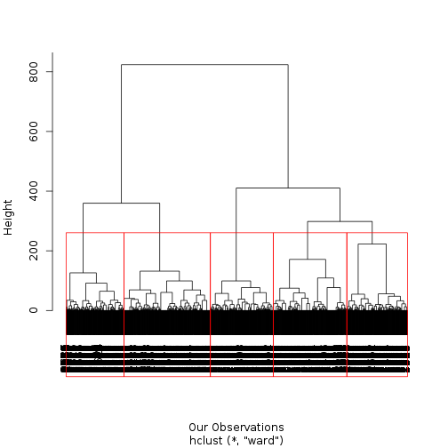

Note that we can draw as many clusters are we choose (e.g. in this case we chose 5 clusters) around the branches of the Dendrogram.

#### Step 7. Profile and interpret the clusters

We can also “visualize” the segments using **snake plots** for each cluster. For example, we can plot the means of the profiling variables for each of our clusters to better visualize differences between segments. For better visualization we plot the standardized profiling variables.

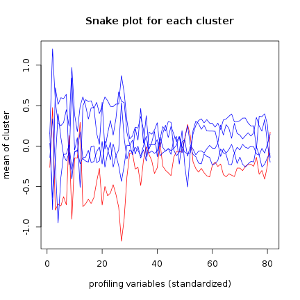

Can we see differences between the segments? Do the segments differ in terms of their average household income and in terms of how often they visit the mall? What else can we say about these segments?

We can also compare the averages of the profiling variables of each segment relative to the average of the variables across the whole population. This can also help us better understand whether there are indeed clusters in our data (e.g. if all segments are much like the overall population, there may be no segments). For example, we can measure the ratios of the average for each cluster to the average of the population (e.g. avg(cluster)/avg(population)) and explore a matrix as the following one:

|  | Segment 1 | Segment 2 | Segment 3 | Segment 4 | Segment 5 |
| --- | --- | --- | --- | --- | --- |
| Q1_1_When buying a boat I do a lot of shopping around and visit multiple dealers | 0.9458 | 1.007 | 1.033 | 1.032 | 0.9708 |
| Q1_2_When buying a boat getting the lowest price is more important than the boat brand | 1.168 | 0.7759 | 0.7234 | 1.423 | 1.119 |
| Q1_3_The brand of boat I buy says a lot about who I am | 0.7404 | 0.9355 | 1.237 | 1.18 | 0.9304 |
| Q1_4_I only consider buying a boat from a reputable brand | 0.8494 | 1.085 | 1.109 | 1.06 | 0.7995 |
| Q1_5_I am willing to pay a premium for a brand with a reputation for high quality | 0.8061 | 1.029 | 1.156 | 1.066 | 0.8975 |
| Q1_6_Owning a boat is a way of rewarding myself for my hard work | 0.8696 | 0.9758 | 1.122 | 1.061 | 0.9788 |
| Q1_7_Owning a boat gives me a sense of achievement | 0.8225 | 0.9552 | 1.156 | 1.11 | 0.9759 |
| Q1_8_When buying a boat functionality is more important than style | 1.029 | 0.9828 | 0.949 | 1.053 | 1.004 |
| Q1_9_I see my boat as a status symbol | 0.6624 | 0.848 | 1.315 | 1.363 | 0.8919 |
| Q1_10_When buying a boat I rely more on expert opinion than my own e g consumer reports salespeople | 0.9595 | 0.9813 | 0.9861 | 1.107 | 0.9791 |
| Q1_11_I tend to perform minor boat repairs and maintenance on my own | 0.9506 | 0.9833 | 1.035 | 1.059 | 0.9802 |
| Q1_12_When it comes to boating I tend to prefer a basic boat with little to no frills | 1.105 | 0.9226 | 0.8184 | 1.173 | 1.063 |
| Q1_13_When buying a boat I tend to buy the latest and greatest | 0.757 | 0.9534 | 1.161 | 1.198 | 0.9495 |
| Q1_14_When buying accessories for my boat I tend to buy the latest and greatest | 0.7866 | 0.9592 | 1.172 | 1.15 | 0.9446 |
| Q1_15_I am serious about the technology on my boat | 0.8383 | 0.9873 | 1.135 | 1.082 | 0.9512 |
| Q1_16_People tend to come to me for advice about boating | 0.7606 | 0.9315 | 1.189 | 1.159 | 0.9992 |
| Q1_17_I consider myself more knowledgeable about boating than the rest of my boating peers | 0.799 | 0.9395 | 1.147 | 1.151 | 1.001 |
| Q1_18_Boating gives me a feeling of adventure | 0.9203 | 0.9875 | 1.098 | 1.029 | 0.963 |
| Q1_19_Boating allows me to experience nature | 0.9528 | 0.998 | 1.069 | 1.003 | 0.9686 |
| Q1_20_When not on my boat I often find myself doing boating related activities | 0.7762 | 0.9315 | 1.153 | 1.167 | 1.018 |
| Q1_21_Boating helps me escape from everyday life and relax | 0.9149 | 1.011 | 1.104 | 0.9931 | 0.9551 |
| Q1_22_Boating helps me stay active | 0.8867 | 0.9928 | 1.103 | 1.029 | 0.9848 |
| Q1_23_Boating allows me to excel in the sports that I am passionate about e g fishing racing water sports | 0.8334 | 0.9509 | 1.141 | 1.091 | 1.014 |
| Q1_24_Boating gives me an outlet to socialize with family and or friends | 0.9121 | 1.005 | 1.09 | 1.025 | 0.9518 |
| Q1_25_Being in charge of my boat is very important to me | 0.8564 | 0.9734 | 1.125 | 1.082 | 0.972 |
| Q1_26_Having a powerful boat is what is most important to me | 0.7311 | 0.9137 | 1.185 | 1.24 | 0.9822 |
| Q1_27_Boating is the number one thing I do with my spare time | 0.6089 | 0.8546 | 1.29 | 1.184 | 1.179 |
| Q1_28_Boating is my true passion in life | 0.734 | 0.9287 | 1.195 | 1.16 | 1.028 |
| Q1_29_Boating is one of many things I do in my spare time | 0.9313 | 1.002 | 1.057 | 1.03 | 0.9709 |
| Q2_How many powerboats do you currently own | 0.9229 | 1.006 | 1.078 | 1.019 | 0.9582 |

[output cut: 51 more lines]

#### Step 8. Assess the robustness of our clusters

We will skip this step for this exercise. However in practice this is a very important step.

## Intepretation, Decisions and Conclusion

We believe that CreeqBoat can actually use this segmantation to design and execute better its business and product strategy. In the earlier explanations, we already identified those critical dimensions which have the strongest differentiating power across the segments and which can be the best use for the company. Based on this, CreeqBoat should either choose a niche strategy and focus on selected 1-2 segments or adjust its product portfolio to the 5 segments with at least 3 different categories: 1. simple basic boats, 2. strong performance boats, 3. high quality luxury boats. Obviously, price categories also should be clearly differentiated, so that the company can meet the different levels of willingness to pay. However, one should also realize, that the development of these 5 categories from the data provided was arbitrary by the nature of diverse data analysis. Obviously, we only had a limited time to work with these data and to develop our segments plus conclusions. As discussed during the class, one could run these analysis forever and still not feel fully convinced about the end results. Also, the potential bias of human information processing came into picture most of the time. When we were trying to develop and describe out selected segments, we unintentionally looked back all the time for our real life experiences, pictured potential boat users and brought in some additional inputs which were not necessary presented in the data. But even beside this, we can conclude that CreeqBoat is definitely provided with more accurate analysis after this description of the 5 segments, than if they only had analyzie the total population averages and deviations for certain questions. It is absolutely critical to find the trade-off between the complexity and deepness of analysis and the additional insights gained from it.